# Mini-Project Presentation

Portia Williams, Zheng Liu

7/26/2019

## Pursuit Project Idea

*Title: Understanding social responses to environmental shocks-A text mining approach*

Theme: Sudden and unexpected events

6 members (US, Africa and Asia)

## From Mini-project to Pursuit

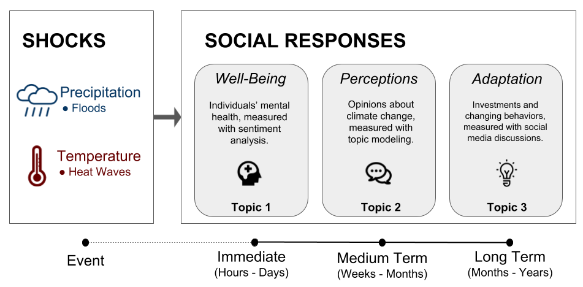

Framework

Pursuit: Scoping stage with 3 sub projects

Mini project related to project 1: Looking at the relationship between weather and sentiment

Aim: Explore approaches for overall contribution to main project

## Methods

- Scraping News Data

  ```
  req = urllib.request.Request(url)
  resp = urllib.request.urlopen(req)
  respData = resp.read()
  ```

- Text Mining

  ```
  paragraphs = re.findall(r'<p>(.*?)</p>',str(respData))
  ```

- Sentiment Analysis
- Regression

Linear Regression

(Sentiments ~ Temperature)

- Interactive mapping

Leaflet map

## Data

### News

Source: [The Gdelt Project](https://www.gdeltproject.org/)

Description: It provides events reported in articles published in the 65 live translated languages. The sample data we used was the latest 15 minute news data at 4pm, Tuesday.

Format: 61 columns total, but we are using id, latitude, longitude, city, origin_url only.

### Weather

Source: [CPC Global Daily Temperature](https://www.esrl.noaa.gov/psd/data/gridded/data.cpc.globaltemp.html)

Description: - CPC .50x.50 Global Daily Temperature - Spatial Coverage: 0.50 - degree latitude x 0.50 - degree longitude grid (720x360). - Updated daily

Format: Max and Min tempertaure NetCDF4 files that can be directly downloaded from the link.

Data examples

|  | id | lat | lon | city | Tmax | Tmin |
| --- | --- | --- | --- | --- | --- | --- |
| 3 | 861174058 | -33.3505 | 18.8702 | Riebeek West, Western Cape, South Africa | 15.23710 | 12.37544 |
| 4 | 861174059 | 8.0000 | -2.0000 |  | 29.45023 | 22.91859 |
| 6 | 861174061 | 40.7834 | -73.9662 | Manhattan, New York, United States | 23.63632 | 17.90541 |
| 7 | 861174062 | 40.7834 | -73.9662 | Manhattan, New York, United States | 23.63632 | 17.90541 |
| 8 | 861174063 | 53.0000 | -8.0000 | United Kingdom | 22.73448 | 16.94893 |

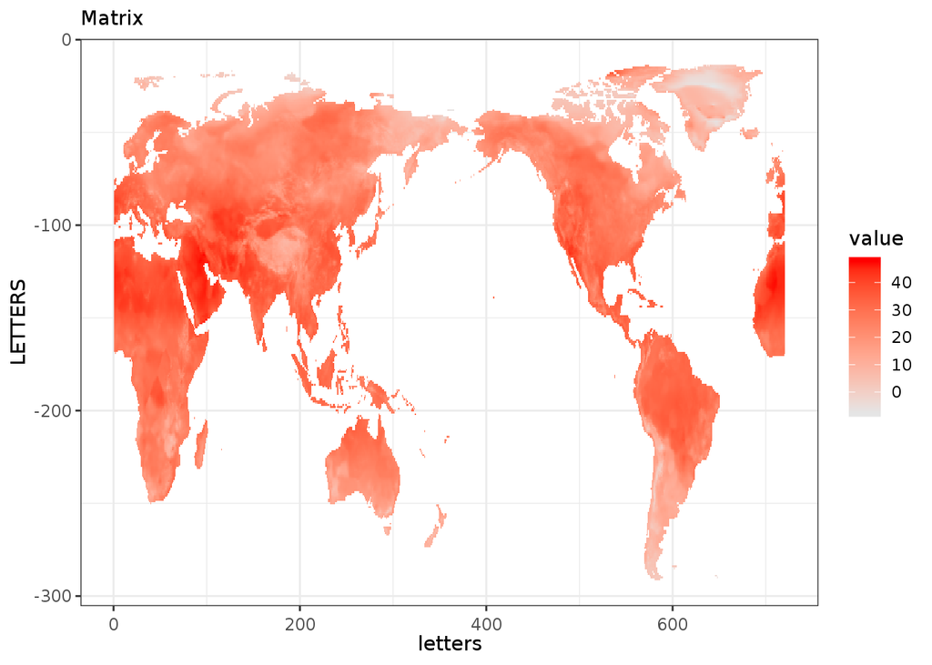

## Results and discussion

### Sentiment Analysis

```r
library(syuzhet)

allData$senti <- get_nrc_sentiment(allData$txt_content)
allData$sentiscore <- get_sentiment(allData$txt_content)
str(allData)
```

```
## 'data.frame':    484 obs. of  9 variables:
##  $ id         : int  861174058 861174059 861174061 861174062 861174063 861174066 861174067 861174070 861174071 861174072 ...
##  $ lat        : num  -33.4 8 40.8 40.8 53 ...
##  $ lon        : num  18.9 -2 -74 -74 -8 ...
##  $ city       : chr  "Riebeek West, Western Cape, South Africa" "" "Manhattan, New York, United States" "Manhattan, New York, United States" ...
##  $ txt_content: chr  "Residents lodged a complaint of hate speech with the police and the SA Human Rights Commission (SAHRC), after a"| __truncated__ "<a rel=\"nofollow\" href=\"artikel.php?ID=766067&nav=previous\">&laquo; Prev</a><a rel=\"nofollow\" href=\"arti"| __truncated__ "AdvertisementSupp…
##  $ Tmax       : num  15.2 29.5 23.6 23.6 22.7 ...
##  $ Tmin       : num  12.4 22.9 17.9 17.9 16.9 ...
##  $ senti      :'data.frame': 484 obs. of  10 variables:
##   ..$ anger       : num  9 0 0 0 0 14 16 0 9 9 ...
##   ..$ anticipation: num  7 0 0 0 4 27 21 0 7 7 ...
##   ..$ disgust     : num  3 0 0 0 0 7 8 0 3 3 ...
##   ..$ fear        : num  7 0 0 0 4 15 17 0 7 7 ...
##   ..$ joy         : num  2 0 0 0 1 14 8 0 2 2 ...
##   ..$ sadness     : num  4 1 0 0 2 13 16 0 4 4 ...
##   ..$ surprise    : num  0 0 0 0 1 6 9 0 0 0 ...
##   ..$ trust       : num  9 0 0 0 6 36 15 0 9 9 ...
##   ..$ negative    : num  13 1 0 0 2 29 27 0 13 13 ...
##   ..$ positive    : num  14 0 0 0 6 44 27 0 14 14 ...
##  $ sentiscore : num  -4.05 0.8 0 0 1.3 2.3 -9.2 0 -4.05 -4.05 ...
```

### Interactive Map

[interactive chart not shown]

### Linear Regression

```r
model1 <- lm(
  formula = sentiscore ~ Tmin,
  data = allData)
summary(model1)
```

```
##
## Call:
## lm(formula = sentiscore ~ Tmin, data = allData)
##
## Residuals:
##     Min      1Q  Median      3Q     Max
## -21.763  -5.616  -3.198   5.876  61.141
##
## Coefficients:
##             Estimate Std. Error t value Pr(>|t|)
## (Intercept)  3.56612    1.40392   2.540   0.0114 *
## Tmin         0.10304    0.08082   1.275   0.2030
## ---
## Signif. codes:  0 '***' 0.001 '**' 0.01 '*' 0.05 '.' 0.1 ' ' 1
##
## Residual standard error: 9.692 on 482 degrees of freedom
## Multiple R-squared:  0.003361,   Adjusted R-squared:  0.001293
## F-statistic: 1.625 on 1 and 482 DF,  p-value: 0.203
```

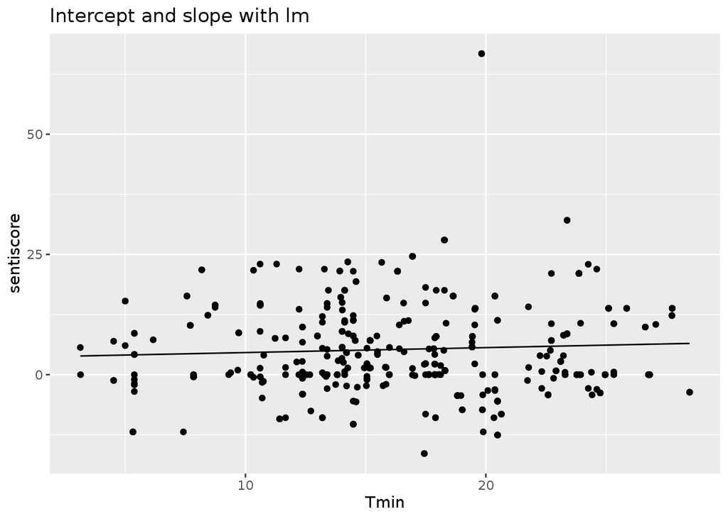

```r
ggplot(allData,
  aes(x = Tmin, y = sentiscore)) +
  geom_point() +
  geom_line(aes(y = predict(model1))) +
  labs(title = 'Intercept and slope with lm')
```

```r
library(lme4)
model2 <- lmer(
  sentiscore ~ (Tmin|Tmax),
  data = allData)
summary(model2)
```

```
## Linear mixed model fit by REML ['lmerMod']
## Formula: sentiscore ~ (Tmin | Tmax)
##    Data: allData
##
## REML criterion at convergence: 3326.5
##
## Scaled residuals:
##     Min      1Q  Median      3Q     Max
## -2.8446 -0.2961 -0.0470  0.1591  3.2952
##
## Random effects:
##  Groups   Name        Variance Std.Dev. Corr
##  Tmax     (Intercept) 29.92388 5.4703
##           Tmin         0.02966 0.1722   1.00
##  Residual             31.08365 5.5753
## Number of obs: 484, groups:  Tmax, 161
##
## Fixed effects:
##             Estimate Std. Error t value
## (Intercept)    4.954      0.723   6.851
## convergence code: 0
## boundary (singular) fit: see ?isSingular
```

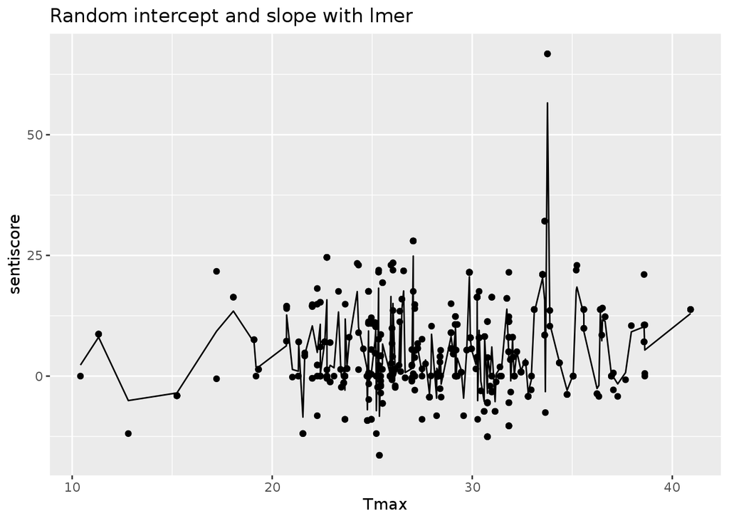

```r
ggplot(allData,
  aes(x = Tmax, y = sentiscore)) +
  geom_point() +
  geom_line(aes(y = predict(model2))) +
  labs(title = 'Random intercept and slope with lmer')
```

### Future Work

1. Integrate text mining methods before the sentiment analysis
2. More precise sentiment measurement
3. Higher quality data for news and temperature

## Thank you!

Safe travel!